# Nietzsche Text Mining Project

To begin I create a character vector of partial urls for each of Nietzsche’s books. They have been made available by the [Gutenberg project](http://www.gutenberg.org/), which is an online resource for free e-books.

```r
nietz_url <- c("files/51356/51356-0", "cache/epub/5652/pg5652", "cache/epub/38226/pg38226",
               "files/51935/51935-0", "files/37841/37841-0", "files/39955/39955-0",
               "files/52881/52881-0", "files/1998/1998-0", "cache/epub/4363/pg4363",
               "files/52319/52319-0", "files/52263/52263-0", "files/52166/52166-0",
               "files/25012/25012-0", "files/52263/52263-0", "files/52190/52190-0",
               "files/52914/52914-0", "files/52915/52915-0")
```

In this section of code an empty character vector is first defined that will hold the full urls for each book. The `make_urls` function creates the full url from the partial urls in `nietz_url`. The full urls are then then saved into `nietz_book_urls`.

```r
urls <- vector()
make_urls <- function(url_temp){
  for (i in 1:length(url_temp)){
    temp_title <- paste("http://www.gutenberg.org/", url_temp[i], ".txt", sep="")
    urls <- rbind(urls, temp_title)
  }
  return(urls)
}
nietz_book_urls <- make_urls(nietz_url)
```

Now the `dplyr` package is imported to use the `data_frame` function, as well as for other features like piping (%>%), etc.

```r
library(dplyr)
full_texts <- data.frame(text=character(), title=character())
read_books <- function(text_urls){
  for (i in 1:length(text_urls)){
    #print(i)
    temp_data <- read.csv(url(text_urls[i]), quote = "", row.names=NULL)

    if (ncol(temp_data)==1) {
      colnames(temp_data) <- "text"
    } else {
      colnames(temp_data) <- c("text1", "text2")
      temp_data$text <- paste(temp_data$text1, temp_data$text2, sep=" ")
    }
    temp_data <- data_frame(text = temp_data$text)
    full_texts <- rbind(full_texts, temp_data)
  }
  return(full_texts)
}
nietz_full_texts <- read_books(nietz_book_urls)
```

Next we ensure that all non-Nietzsche text (i.e. translator introductions and forewords) is excluded from our data set. Given the inconsistency in text structure across the individual books, the relevant text is selected with row numbers rather regular expressions, with the book names assigned to a new column `title`. Excluded text is labeled as ‘Supplementary Texts’.

```r
nietz_rows <- as.numeric(rownames(nietz_full_texts))
nietz_full_texts$title <-
  ifelse(nietz_rows >= 652 & nietz_rows <= 5817, "The Birth of Tragedy",
  ifelse(nietz_rows >= 7695 & nietz_rows <= 15957, "Thoughts Out of Season: Part 1",
  ifelse(nietz_rows >= 16482 & nietz_rows <= 21295, "Thoughts Out of Season: Part 2",
  ifelse(nietz_rows >= 21770 & nietz_rows <= 31013, "Human, All Too Human: Part 1",
  ifelse(nietz_rows >= 31426 & nietz_rows <= 39569, "Human, All Too Human: Part 2",
  ifelse(nietz_rows >= 40186 & nietz_rows <= 50115, "The Dawn of Day",
  ifelse(nietz_rows >= 50577 & nietz_rows <= 60293, "The Joyful Wisdom",
  ifelse(nietz_rows >= 61266 & nietz_rows <= 72131, "Thus Spoke Zarathustra",
  ifelse(nietz_rows >= 74236 & nietz_rows <= 81292, "Beyond Good and Evil",
  ifelse(nietz_rows >= 81674 & nietz_rows <= 87977, "The Genealogy of Morals",
  ifelse(nietz_rows >= 88610 & nietz_rows <= 91934, "The Twilight of the Idols",
  ifelse(nietz_rows >= 91939 & nietz_rows <= 96155, "The Antichrist",
  ifelse(nietz_rows >= 97027 & nietz_rows <= 98372, "The Case of Wagner",
  ifelse(nietz_rows >= 98420 & nietz_rows <= 99601, "Nietzsche Contra Wagner",
  ifelse(nietz_rows >= 99680 & nietz_rows <= 101793, "We Philologists",
  ifelse(nietz_rows >= 114027 & nietz_rows <= 119452, "Ecce Homo",
  ifelse(nietz_rows >= 120049 & nietz_rows <= 128916, "The Will to Power: Books 1 & 2",
  ifelse(nietz_rows >= 129623 & nietz_rows <= 139729, "The Will to Power: Books 3 & 4",
                                                      "Supplementary Texts"))))))))))))))))))
```

Stop words are highly common words, such as *the* and *if*, that are in many ways uninformative for topic modeling and need to be removed. This is done below with a list called `stop_words` provided by the `tidytext` library.

I also define a list of custom stop words for archaic English that is used in some of the translations of Nietzsche’s books. After that any remaining underscores that are still present due to abnormal punctuation and spacing are removed.

```r
library(tidytext)
data(stop_words)
custom_stop_words <- data_frame(word = c("ye", "thou", "thee", "hast", "dost", "shalt",
                                         "didst", "hath", "thy", "ni"))

nietz_full_texts$text <- gsub("_", "", nietz_full_texts$text)
```

Now it is time to *tokenize* the words (i.e. make one word per row) with `unnest_tokens` while also filtering out stop words. The `group_by` function (from dplyr) allows the grouping of variables, such that operations are performed separately for given levels within a variable. The `mutate` function (also from dplyr) is then used to create a new variable (i.e. new column) that contains the row number for each line of text. The text is then ungrouped, and the `unnest_tokens` function (from tidytext) places each word into a single row. And then we ensure that the supplementary texts are excluded, as well as the stop words from `stop_words` and `custom_stop_words`. The data is now in tidy format.

```r
nietz_tidy <- nietz_full_texts %>% group_by(title) %>%
  mutate(line_number=row_number()) %>% ungroup(title) %>%
  unnest_tokens(word, text) %>%
  filter(title != "Supplementary Texts") %>%
  filter(!word %in% stop_words$word) %>%
  anti_join(custom_stop_words, by = "word")
```

On to the word cloud! To begin, the `wordcloud` library is loaded and the background and color scheme of the word cloud are defined. The word frequency is tallied with the function `count` (from dplyr). The top 100 most frequent words are included in the plot. It reflects the most utilized words, apart from stop words, throughout all of his books, and is a marker for the topics Nietzsche discusses in general.

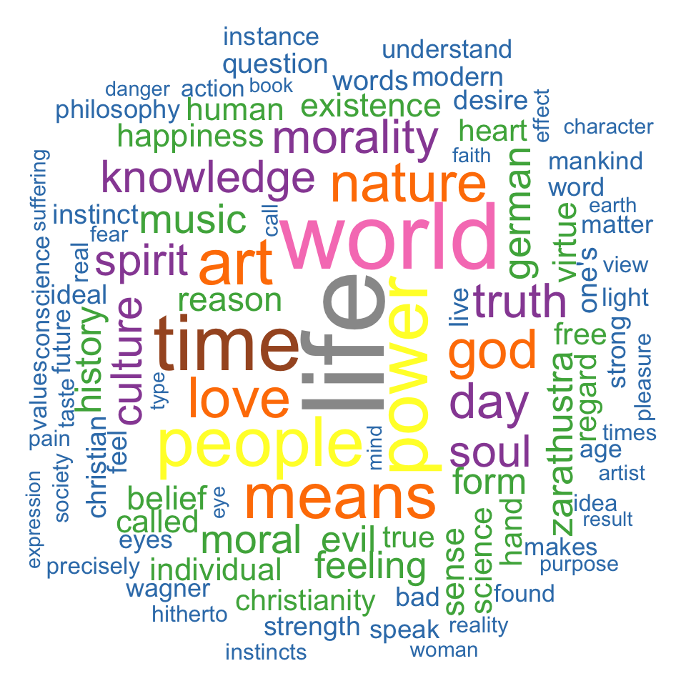

```r
library(wordcloud)
par(bg="white")
pal2 <- brewer.pal(9,"Set1")

nietz_tidy %>%
  count(word) %>%
  with(wordcloud(word, n, scale=c(5,.2),min.freq=2,max.words=100,
            random.order=FALSE, rot.per=.25, colors=pal2))
```

Here the *term-frequency-inverse-document-frequency* (tf-idf) is calculated for each word. This is a way of analyzing a term’s uniqueness within each individual book.

First a list `nietz_book_words` is created that contains all of Nietzsche’s words counted separately for each book. Another variable `nietz_total_words` is used to count the total number of words used within each book. The ‘total words’ column from `nietz_total_words` is then attached to `nietz_book_words` via `left_join`.

```r
nietz_book_words <- nietz_tidy %>%
  count(title, word, sort = TRUE)

nietz_total_words <- nietz_book_words %>%
  group_by(title) %>% summarize(total = sum(n)) %>%
  ungroup()

nietz_book_words <- left_join(nietz_book_words, nietz_total_words)
```

The tf-idf is calculated separately for each word within each book using `bind_tf_idf` from the `tidytext` library. After that the data are rearranged in `nietz_book_words`, such that the words with the highest tf-idf appear at the top of the column. The ‘word’ column is also converted into a factor, with the levels being equal to the reverse number of times a word appears (see `rev`). After the 6 books that I am interested in are selected, with each book being filtered for the 15 words with the highest tf-idf.

```r
nietz_book_words <- nietz_book_words %>%
  bind_tf_idf(word, title, n)

plot_nietz <- nietz_book_words %>% arrange(desc(tf_idf)) %>%
  mutate(word = factor(word, levels = rev(unique(word))))

plot_nietz_bar <- plot_nietz %>%
  filter(title=="Thoughts Out of Season: Part 1" |
                       title=="Thoughts Out of Season: Part 2" |
                       title=="The Dawn of Day" |
                       title=="We Philologists" |
                       title=="The Will to Power: Books 1 & 2" |
                       title=="The Will to Power: Books 3 & 4") %>%
  group_by(title) %>% top_n(15) %>% ungroup()
```

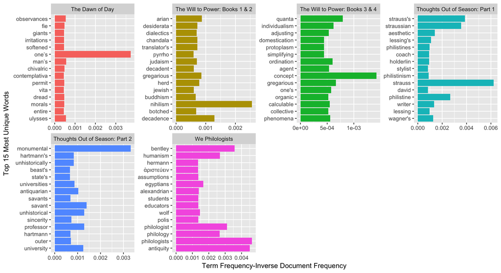

Next the lists `wephil` and `seaout` are created to hold text from the books *We Philologists* and *Thoughts Out of Season: Part 2*, respectively.

```r
wephil <- nietz_full_texts %>% filter(title=="We Philologists")

seaout <- nietz_full_texts %>% filter(title=="Thoughts Out of Season: Part 2")
```

A function `make_book_sections` is then defined, which divides each book into 10 separate (but equally sized) sections. The column `section` is also created to indicate the ‘section’ number for each line of text.

```r
make_book_sections <- function(input_txt){
  var1 <- input_txt %>% group_by(title) %>%
    mutate(line_number = row_number(), total_lines = n(),
           line_proportion = line_number/total_lines) %>% ungroup()

  var2 <- ifelse(var1$line_proportion <= 0.1, "section_1",
          ifelse(var1$line_proportion > 0.1 & var1$line_proportion <= 0.2, "section_2",
          ifelse(var1$line_proportion > 0.2 & var1$line_proportion <= 0.3, "section_3",
          ifelse(var1$line_proportion > 0.3 & var1$line_proportion <= 0.4, "section_4",
          ifelse(var1$line_proportion > 0.4 & var1$line_proportion <= 0.5, "section_5",
          ifelse(var1$line_proportion > 0.5 & var1$line_proportion <= 0.6, "section_6",
          ifelse(var1$line_proportion > 0.6 & var1$line_proportion <= 0.7, "section_7",
          ifelse(var1$line_proportion > 0.7 & var1$line_proportion <= 0.8, "section_8",
          ifelse(var1$line_proportion > 0.8 & var1$line_proportion <= 0.9, "section_9",
          ifelse(var1$line_proportion > 0.9 & var1$line_proportion <= 1.0, "section_10",
                 "NA"))))))))))
  var1$section <- var2
  return(var1)
}
```

The `tidyr` library is loaded in order to use the `unite` function. The `make_book_sections` function divides each book into 10 sections. The `section` and `title` variables are also concatenated into a single variable called `document`.

```r
library(tidyr)
by_section_wephil <- make_book_sections(wephil) %>%
  unite(document, title, section) %>% select(text, document)

by_section_seaout <- make_book_sections(seaout) %>%
  unite(document, title, section) %>% select(text, document)
```

Here the text is tokenized and tidied, and then the stop words are removed. The words are then counted and sorted from highest to lowest.

```r
by_section_tidy_wephil <- by_section_wephil %>%
  unnest_tokens(word, text) %>% anti_join(stop_words) %>% anti_join(custom_stop_words) %>%
  count(document, word, sort = TRUE)

by_section_tidy_seaout <- by_section_seaout %>%
  unnest_tokens(word, text) %>% anti_join(stop_words) %>% anti_join(custom_stop_words) %>%
  count(document, word, sort = TRUE)
```

Now a Document Term Matrix for both books must be created in order to conduct the LDA analysis.

```r
sections_dtm_wephil <- by_section_tidy_wephil %>%
  cast_dtm(document, word, n)

sections_dtm_seaout <- by_section_tidy_seaout %>%
  cast_dtm(document, word, n)
```

The *Latent Dirichlet Allocation* (LDA) model is run with `LDA` that comes from the library `topicmodels`. Ten (k) topics are specified for each book, and is seeded with 1234, rather than a random number, for reproducibility purposes.

```r
library(topicmodels)

sections_lda_wephil <- LDA(sections_dtm_wephil, k = 10, control = list(seed = 1234))

sections_lda_seaout <- LDA(sections_dtm_seaout, k = 10, control = list(seed = 1234))
```

The output of the LDA function, which was saved in the variables `sections_lda_wephil` and `sections_lda_seaout`, contains beta values for each word showing the degree to which each word matches the given topic in which it is grouped.

Now that we have beta values for each word, we re-tidy the data, and then we find the words with the highest beta values within each of the 10 topics that were generated by `LDA`.

```r
top_terms_wephil <- tidy(sections_lda_wephil, matrix = "beta") %>%
  group_by(topic) %>% top_n(5, beta) %>% ungroup() %>% arrange(topic, -beta)

top_terms_seaout <- tidy(sections_lda_seaout, matrix = "beta") %>%
  group_by(topic) %>% top_n(5, beta) %>% ungroup() %>% arrange(topic, -beta)
```

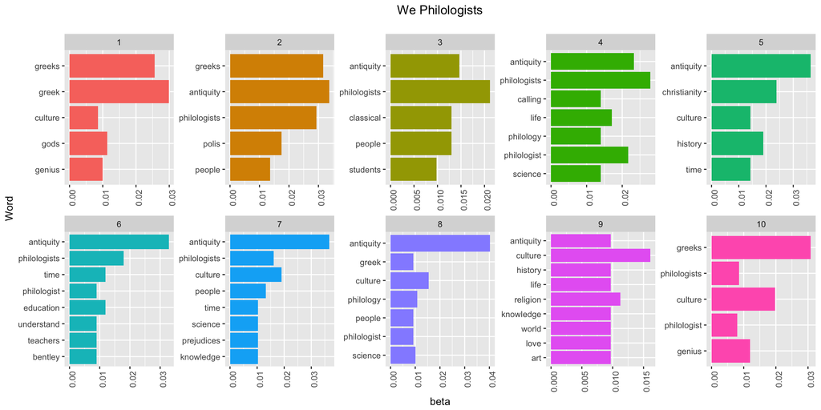

```r
top_terms_wephil %>%
  mutate(term = reorder(term, beta)) %>%
  ggplot(aes(term, beta, fill = factor(topic))) + geom_col(show.legend = FALSE) +
  labs(x = "Word", title = "We Philologists\n") +
  facet_wrap(~ topic, ncol=5, scales = "free") + coord_flip() +
  theme(axis.text.x = element_text(angle = 90, hjust = 1), plot.title = element_text(hjust = 0.5))
```

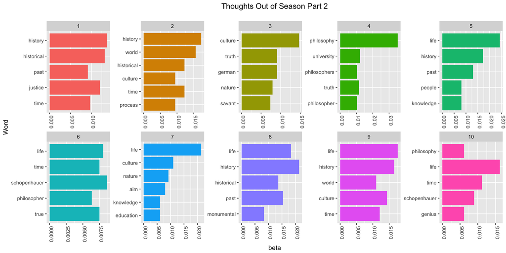

```r
top_terms_seaout %>%
  mutate(term = reorder(term, beta)) %>%
  ggplot(aes(term, beta, fill = factor(topic))) + geom_col(show.legend = FALSE) +
  labs(x = "Word", title = "Thoughts Out of Season Part 2\n") +
  facet_wrap(~ topic, ncol=5, scales = "free") + coord_flip() +
  theme(axis.text.x = element_text(angle = 90, hjust = 1), plot.title = element_text(hjust = 0.5))
```

For information on the *Latent Dirichlet Allocation* model, see this [link](https://cran.r-project.org/web/packages/topicmodels/vignettes/topicmodels.pdf).